# 1. Import required libraries and read the provided dataset (youtube_dislike_dataset.csv) and retrieve top5 and bottom 5 records.

# 12. Find the title of the video which has the maximum number of dislikes and the title of the video having minimum dislikes and write your inferences.

```python
max_dislikes = df['dislikes'].idxmax()
max_dislikes
```

```
13591
```

```python
min_dislikes = df['dislikes'].idxmin()
min_dislikes
```

```
18654
```

```python
max_title_dis = df.loc[max_dislikes, 'title']
max_title_dis
```

```
'Cuties | Official Trailer | Netflix'
```

```python
min_title_dis = df.loc[min_dislikes, 'title']
min_title_dis
```

```
'Kim Kardashian\'s Must-See Moments on "Saturday Night Live" | E! News'
```

# Inferences (Maximum number of dislikes)

*The maximum value in the "dislikes" column is associated with the row whose index value is **"13591".**

*The minimum value in the "dislikes" column is associated with the row whose index value is **"18654".**

# 13. Does the number of views have any effect on how many people disliked the video? Support your answer with a metric and a plot.

```python
correlation = df['view_count'].corr(df['dislikes'])
correlation
```

```
0.6844687753905547
```

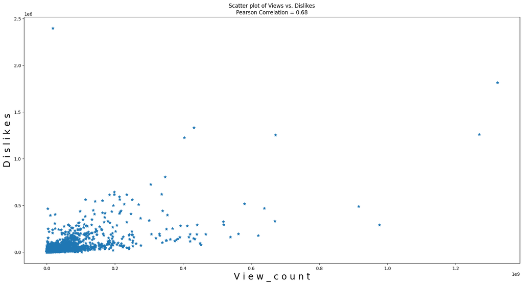

```python
plt.figure( figsize=(20,10))
symbol = "*"
plt.scatter(df['view_count'], df['dislikes'],marker=symbol)
plt.xlabel('V i e w _ c o u n t',fontsize=20)
plt.ylabel('D i s l i k e s', fontsize=20)
plt.title('Scatter plot of Views vs. Dislikes\nPearson Correlation = {:.2f}'.format(correlation))
plt.show()
```

# 14.Display all the information about the videos that were published in January, and mention the count of videos that were published in January.

```python
january_videos = df[df['published_month'] == 'Jan']
print(january_videos)

january_video_count = january_videos.shape[0]
print("Number of videos published in January:", january_video_count)
```

```
          video_id                                              title  \
27     -2Gwm7QfBnE                                    Q&A With Naisha
48     -4sfXSHSxzA           SURPRISING BRENT WITH HIS TIKTOK CRUSH!!
95     -AJD1Fc5rpQ  WE ARE HAVING A BABY! | finding out i'm pregna...
103    -AuJiwjsmWk              Do Ugly Foods Taste Worse? Taste Test
182    -JhqO2KWr5U                                   Schlatt gets fit
...            ...                                                ...
37300  zmzFL5bG-jc  DEVINE MON PERSONNAGE AVANT AKINATOR ! (c'est ...
37329  zpzjex7qwrA  Lampard Sacked Within Days Rorys Misery | Chel...
37345  zqyv-B6mnBM                 Lil Wayne - Ain't Got Time (Audio)
37383  zwfu1-24T7Q  PRADA Cup Day 1 | Full Race Replay | PRADA Cup...
37418  zziBybeSAtw  PELICANS at LAKERS | FULL GAME HIGHLIGHTS | Ja...

                     channel_id       channel_title        published_at  \
27     UCYwNMbogQFzMccPSuy-pPWg           MianTwins 2021-01-21 00:05:47
```

[output cut: 65 more lines]